# Day One - Assessment

UBEP’s R training for supervisors

# Visualization

**Learning Objectives**

At the end of the assessment, participants should have demonstrated their ability to: (1) (2)

- Use the native pipe (`|>`) and the `{ggplot2}` plus-sign (`+`) correctly
- Use the `{rio}` (`import`) for general-purpose import. (2)
- Create general plots using `{ggplot2}` package and corresponding grammar; in particular:
  - select/use tidy-data for a plot
  - understand the meaning of “aesthetics” (`aes`)
  - know the use and the basic geometries (`geom_*`)
  - ability to facet a plot (`facet`)
  - be able to modify the basic plot style (`theme` and `labs`)
  - be aware that axes can be modified (e.g., `coord_flip`) and geometries can be personalized (e.g., `position = “dodge”`)

# Preamble

**Instructions**

This section is for context only. Nothing has to be done in this section by the participants.

**Instructions**

This assessment is the second of four ones regarding the UBEP’s **R training for supervisors** for the ECDC.

To solve the exercise follow the text and find the assessments in which you need to fill the `___` where required in the code. Next, go to the corresponding section of the R script `solution.R` and try/run sequentially your code.

All the exercise are presented in a tabset panel with a tab containing all the missing parts, and a tab with the solved, completed (including output) code. This version of the file has the solution exposed.

**RStudio cloud**

You can access to a dedicated R/RStudio environment on Posit Cloud at connecting [here](https://posit.cloud/spaces/455124/join?access_code=DHjcv_CtTVioVEoCQTqHwYFs1-N5zyPVnl7bW_K4). You need to create a free account on Posit Cloud, and next accept to join the “R training for supervisors” workspace. Inside that space, you can enter in the “day-2” project, and find inside all the data, script and resources useful to complete the assessment.

**Attribution**

The text and examples in the present document are UBEP’s variation/adaptation from the ECDC EPIET Outbreak Investigation, that can be found on GitHub at https://github.com/EPIET/OutbreakInvestigation.(3)

**Copyright & License**

The present work is released under the GPL-3 License.

# Environment preparation

**Instructions**

In this section, participants should attach to the R session the following packages using the `library` function: (2)

- `tidyverse`
- `here`
- `rio`

Moreover, they need to correctly pipe the instructions to read the data.

> Task: fill in `___` the proper function/command

**Exercise**

```r
___(tidyverse)
___(here)
___(rio)

linelist <- here("data-raw/Copenhagen_clean.xlsx") ___
  ___() ___
  mutate(across(where(is.character), fct))
```

**Solution**

```r
library(tidyverse)
library(here)
library(rio)

linelist <- here("data-raw/Copenhagen_clean.xlsx") |>
  import() |>
  mutate(across(where(is.character), fct))
```

# Data preparation

**Instructions**

This section is for context only. Nothing has to be done in this section by the participants.

**Context**

### The Alert

On November 14th 2006 the director of a high school in Greater Copenhagen, Denmark, contacted the regional public health authorities to inform them about an outbreak of diarrhoea and vomiting among participants from a school dinner party held on the 11th of November 2006. Almost all students and teachers of the school (750 people) attended the party.

The first people fell ill the same night and by 14 November, the school had received reports of diarrhoeal illness from around 200 - 300 students and teachers, many of whom also reported vomiting.

### Your mission

Your group has been tasked with investigating this outbreak; you have just received the information above.

**Data import**

The epidemiologists in the outbreak team decided to perform a retrospective cohort study in order to identify the food item that was the vehicle of the outbreak. The cohort was defined as students and teachers who had attended the party at the high school on 11th of November 2006.

A questionnaire was designed to conduct a survey on food consumption and on presentation of the illness. Information about the survey and a link to the questionnaire was circulated to students and teachers via the school’s intranet with the request that everyone who attended the school party on 11th of November 2006 should fill in the questionnaire.

Practically all students and teachers check the intranet on a daily basis, because it is the school’s main communication channel for information about courses, homework assignments, cancellation of lessons etc. The school’s intranet was accessible for ill students or teachers from home so that everyone in the cohort could potentially participate and the response rate could be maximised. Additionally, the information about the investigation was also displayed on the screen in the main hall of the school.

### Exploring the data

Before you can begin analysing the data, you will need to become familiar with its contents and check for any errors, or values that don’t make sense.

**Preprocessing**

For this assessment all the data preprocessing is already done. Participants will find the data already in their environment named as `linelist`.

In the following:

- The variables are grouped by type (e.g. character or numeric)
- n_missing shows the number of observations with missing values for each variable
- complete_rate shows the proportion of observations that are not missing
- `min` and `max` for character variables refer to the number of characters per string
- `p0` and `p100` for numeric variables refer to minimum and maximum values, respectively.
- For more details, see the help file by typing `?skimr::skim` in the console

```r
skimr::skim(linelist)
```

Data summary

| Name | linelist |
| --- | --- |
| Number of rows | 384 |
| Number of columns | 46 |
| _______________________ |  |
| Column type frequency: |  |
| factor | 3 |
| logical | 24 |
| numeric | 16 |
| POSIXct | 3 |
| ________________________ |  |
| Group variables | None |

**Variable type: factor**

| skim_variable | n_missing | complete_rate | ordered | n_unique | top_counts |
| --- | --- | --- | --- | --- | --- |
| sex | 0 | 1.00 | FALSE | 2 | fem: 219, mal: 165 |
| group | 0 | 1.00 | FALSE | 2 | stu: 369, tea: 15 |
| class | 35 | 0.91 | FALSE | 3 | 1: 134, 3: 112, 2: 103 |

**Variable type: logical**

| skim_variable | n_missing | complete_rate | mean | count |
| --- | --- | --- | --- | --- |
| diarrhoea | 132 | 0.66 | 0.82 | TRU: 206, FAL: 46 |
| bloody | 190 | 0.51 | 0.03 | FAL: 189, TRU: 5 |
| vomiting | 169 | 0.56 | 0.31 | FAL: 149, TRU: 66 |
| abdo | 142 | 0.63 | 0.86 | TRU: 207, FAL: 35 |
| nausea | 160 | 0.58 | 0.75 | TRU: 169, FAL: 55 |
| fever | 213 | 0.45 | 0.26 | FAL: 127, TRU: 44 |
| headache | 164 | 0.57 | 0.62 | TRU: 137, FAL: 83 |
| jointpain | 196 | 0.49 | 0.15 | FAL: 159, TRU: 29 |
| meal | 0 | 1.00 | 1.00 | TRU: 384 |
| tuna | 4 | 0.99 | 0.72 | TRU: 272, FAL: 108 |
| shrimps | 5 | 0.99 | 0.67 | TRU: 255, FAL: 124 |
| green | 18 | 0.95 | 0.59 | TRU: 216, FAL: 150 |
| veal | 3 | 0.99 | 0.89 | TRU: 340, FAL: 41 |
| pasta | 3 | 0.99 | 0.89 | TRU: 338, FAL: 43 |
| rocket | 12 | 0.97 | 0.57 | TRU: 211, FAL: 161 |
| sauce | 30 | 0.92 | 0.42 | FAL: 205, TRU: 149 |
| bread | 6 | 0.98 | 0.91 | TRU: 345, FAL: 33 |
| champagne | 13 | 0.97 | 0.87 | TRU: 323, FAL: 48 |
| beer | 18 | 0.95 | 0.78 | TRU: 286, FAL: 80 |
| redwine | 38 | 0.90 | 0.23 | FAL: 265, TRU: 81 |
| whitewine | 19 | 0.95 | 0.73 | TRU: 266, FAL: 99 |
| gastrosymptoms | 0 | 1.00 | 0.56 | TRU: 216, FAL: 168 |
| ate_anything | 0 | 1.00 | 1.00 | TRU: 384 |
| case | 0 | 1.00 | 0.56 | TRU: 216, FAL: 168 |

**Variable type: numeric**

| skim_variable | n_missing | complete_rate | mean | sd | p0 | p25 | p50 | p75 | p100 | hist |
| --- | --- | --- | --- | --- | --- | --- | --- | --- | --- | --- |
| id | 0 | 1.00 | 215.80 | 123.65 | 1 | 111.75 | 216.5 | 318.25 | 435 | ▇▇▇▇▇ |
| age | 0 | 1.00 | 18.30 | 6.13 | 15 | 16.00 | 17.0 | 18.00 | 65 | ▇▁▁▁▁ |
| starthour | 166 | 0.57 | 12.52 | 4.94 | 3 | 9.00 | 9.0 | 15.00 | 21 | ▁▇▁▆▃ |
| tunaD | 4 | 0.99 | 1.32 | 1.00 | 0 | 0.00 | 2.0 | 2.00 | 3 | ▆▅▁▇▂ |
| shrimpsD | 5 | 0.99 | 1.35 | 1.04 | 0 | 0.00 | 2.0 | 2.00 | 3 | ▆▂▁▇▂ |
| greenD | 18 | 0.95 | 1.14 | 1.05 | 0 | 0.00 | 1.0 | 2.00 | 3 | ▇▂▁▇▂ |
| vealD | 2 | 0.99 | 1.83 | 0.90 | 0 | 1.00 | 2.0 | 2.00 | 3 | ▂▃▁▇▃ |
| pastaD | 3 | 0.99 | 1.81 | 0.91 | 0 | 1.00 | 2.0 | 2.00 | 3 | ▂▃▁▇▃ |
| rocketD | 12 | 0.97 | 1.08 | 1.06 | 0 | 0.00 | 1.0 | 2.00 | 3 | ▇▂▁▆▂ |
| sauceD | 30 | 0.92 | 0.83 | 1.06 | 0 | 0.00 | 0.0 | 2.00 | 3 | ▇▁▁▃▁ |
| breadD | 6 | 0.98 | 1.75 | 0.71 | 0 | 2.00 | 2.0 | 2.00 | 3 | ▁▂▁▇▁ |
| champagneD | 13 | 0.97 | 1.37 | 0.93 | 0 | 1.00 | 1.0 | 2.00 | 3 | ▂▇▁▂▃ |
| beerD | 23 | 0.94 | 1.95 | 1.23 | 0 | 1.00 | 3.0 | 3.00 | 3 | ▃▂▁▂▇ |
| redwineD | 40 | 0.90 | 0.45 | 0.92 | 0 | 0.00 | 0.0 | 0.00 | 3 | ▇▁▁▁▁ |
| whitewineD | 24 | 0.94 | 1.58 | 1.21 | 0 | 0.00 | 2.0 | 3.00 | 3 | ▆▅▁▅▇ |
| incubation | 168 | 0.56 | 19.03 | 7.93 | 3 | 15.00 | 15.0 | 21.00 | 45 | ▂▇▇▁▁ |

**Variable type: POSIXct**

| skim_variable | n_missing | complete_rate | min | max | median | n_unique |
| --- | --- | --- | --- | --- | --- | --- |
| dayonset | 164 | 0.57 | 2006-11-11 00:00:00 | 2006-11-13 00:00:00 | 2006-11-12 00:00:00 | 3 |
| onset_datetime | 164 | 0.57 | 2006-11-11 00:00:00 | 2006-11-13 15:00:00 | 2006-11-12 09:00:00 | 9 |
| meal_datetime | 0 | 1.00 | 2006-11-11 18:00:00 | 2006-11-11 18:00:00 | 2006-11-11 18:00:00 | 1 |

**Case definition**

**Variables of interest:**

Your exposure of interest is the school dinner party held on 11 November 2006 at 18:00. You may have noticed while skimming the data, that there is a binary variable called `meal`. This variable indicates whether people attended the school dinner party and ate a meal there, or not.

Other variables that will be helpful to include in your case definition are `onset_datetime` (hint: check that case onset date/time is **after** exposure) and symptom variables (hint: not everyone on the linelist fell ill). The symptoms included in the data set are:

- `abdo` (abdominal pain)
- `diarrhoea`
- `bloody` (bloody diarrhoea)
- `nausea`
- `vomiting`
- `fever`
- `headache`
- `jointpain`

### Defining a case

A case was defined as a person who:

- attended the school dinner on 11 November 2006 (i.e. is on the linelist)
- ate a meal at the school dinner (i.e. was exposed)
- fell ill after the start of the meal
- fell ill no later than two days after the school dinner
- suffered from diarrhoea with or without blood, or vomiting

Non cases were defined as people who:

- attended the school dinner on 11 November 2006 (i.e. are on the linelist)
- ate a meal at the school dinner (i.e. were exposed)
- did not fall ill within the time period of interest
- did not develop diarrhoea (with or without blood) or vomiting

For the sake of the analysis, we excluded any people from the cohort who didn’t eat at the dinner, because we specifically hypothesise a food item to be the vehicle of infection in this outbreak. Excluding people reduces the sample size and therefore the power slightly, but the investigators considered that this would increase specificity.

The variables needed to define this case definition are:

- `meal`
- `onset_datetime`
- `diarrhoea`
- `bloody`
- `vomiting`

For the case definition, we are primarily interested in three symptoms:

- `diarrhoea` (without blood)
- `bloody` (diarrhoea with blood)
- `vomiting`

However, these are not the only symptoms in the data set. When creating the case definition, it would be easier to refer to these three symptoms if there was one column, indicating whether people had those symptoms or not. We can call this column `gastrosymptoms`.

Next, we created a column for the case definition, in which we defined all the respondents as either cases, non-cases or `NA`.

We can define non-cases as those who attended the meal, but didn’t develop any gastro symptoms, or if they did, developed them before the meal took place.

We can exclude (define as `NA`) respondents that answered the survey, but did not attend the meal.

### Incubation times

A suitable incubation period to use in the case definition can be defined by calculating the time between exposure (to the meal) and onset of symptoms, and then looking at the distribution of these time differences. In this outbreak, incubation periods are easy to calculate, because everyone was exposed at (roughly) the same time and on the same day (eating the meal at the school dinner party).

We can see that the onset dates of all cases were from 11 to 13 November 2006 inclusive; this is why case numbers didn’t change when we updated the case definition.

### Exclusions

Ultimately, the investigation team decided to remove respondents that did not meet the definition for a case or a non-case from the data set prior to analysis.

# Descriptive Analyses

**Instructions**

In this section, participants should fill in `___` the proper function/command.

**Introduction**

### Goals

In this session, we will perform some descriptive analysis. Typically, we would describe the outbreak in terms of time, place and person. In this data set, we don’t have geospatial information, but we do have time (onset dates and times, incubation periods) and person (age, sex, clinical symptoms). You will:

- Describe cases by age and sex
- Describe case symptoms
- Describe and illustrate incubation periods
- Create an epidemic curve

Many of the descriptive features can be illustrated graphically, for which we will use the package `ggplot2`.

**Analisys Plan**

In theory, you create an analysis plan before data collection - it is an important way to ensure you collect all the data you need and that you *only* collect the data you need (think: data protection!). However, during outbreak investigations, you may need to deploy questionnaires as soon as possible and before a plan has been developed. In these cases, your experience will be an important resource to fall back on.

In your analysis plan you should create a document to include:

- research question(s) and hypothesis
- dataset(s) to be used
- inclusion / exclusion criteria for records you will use in your analysis
- list of variables that will be used in the main analysis;
  - outcome variable (being a case)
  - main exposure variables (e.g. food consumed)
  - stratifying variables (e.g. age, sex, group, class)
- statistical methods
- key mock-up tables including title, labels and expected format for results
  - univariable
  - bivariable
  - stratified

**Time**

### Incubation period

> The incubation period of a disease is the time from an exposure resulting in infection until the onset of disease. Because infection usually occurs immediately after exposure, the incubation period is generally the duration of the period from the onset of infection to the onset of disease. (6)

In the previous section, we calculated incubation period by subtracting the meal date and time from the date and time of symptom onset. This gave us the incubation period in hours. We can now look at this on a graph:

**Plot of incubation period:**

**Instructions**

Produce a `histogram` of the `incubation` period variable (with missing values dropped out), using the `ggplot` function.

Set the following labels:

- x axis: “Incubation period in 6-hour bins”
- y axis: “Number of cases”

**Exercise**

```r
incplot <- linelist |>

  # Remove missing values:
  drop_na(incubation) |>

  # Create an empty ggplot frame setting `incubation` as aesthetic:
  ___(___(x = ___)) +

  # Add a histogram of incubation using the appropriate geom_*:
  ___(
    # Set bin widths to 6 hours:
    binwidth = 6
  ) +

  # Adapt scale to better fit data
  scale_x_continuous(breaks = seq(0, 48, 6)) +

  # Set the required labs to the x and y axes:
  ___(
    x = ___,
    y = ___
  )

# Print plot:
incplot
```

**Solution**

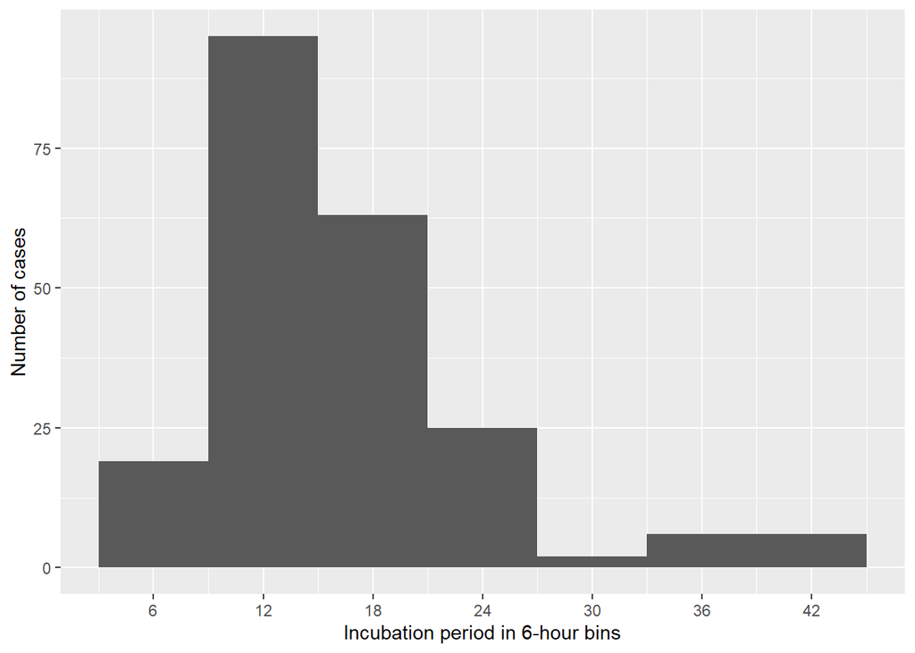

```r
incplot <- linelist |>

  # Remove missing values:
  drop_na(incubation) |>

  # Create an empty ggplot frame:
  ggplot(aes(x = incubation)) +

  # Add a histogram of incubation:
  geom_histogram(
    # Set bin widths to 6 hours:
    binwidth = 6
  ) +

  # Adapt scale to better fit data
  scale_x_continuous(breaks = seq(0, 48, 6)) +

  # Label x and y axes:
  labs(
    x = "Incubation period in 6-hour bins",
    y = "Number of cases"
  )

# Print plot:
incplot
```

### Epidemic curve

To create an *epicurve*, we are going to use `ggplot2`. `ggplot2` is a versatile package that helps create beautiful visualizations in `R`. There are plenty good in-depth guides to the package, for example: [*The Epidemiologist R Handbook* Chapter on *ggplot*](https://epirhandbook.com/en/ggplot-basics.html) and [*ggplot2 - Elegant Graphics for Data Analysis*](https://ggplot2-book.org/index.html).

First, we can create an epicurve for the date of onset, limiting the input data to cases:

**Instructions**

Produce a daily epicurve using a `barplot` of the `dayonset` variable (considering `case` only, and with missing values dropped out), using the `ggplot` function.

Set the following labels:

- x axis: “Date of onset”
- y axis: “Number of cases”

**Exercise**

```r
# Fetch data:
epicurve_date <- linelist |>

  # Filter for cases where dayonset is not missing:
  filter(
    case == TRUE,
    !is.na(dayonset)
  ) ___

  # Add dayonset to ggplot aesthetic:
  ggplot(aes(x = dayonset)) ___

  # Add the proper `geom_*` for a barplot:
  ___() +

  # Adapt scale to data and adjust axis label angle:
  scale_x_datetime(
    date_breaks = "1 day",
    labels = scales::label_date_short()) +

  # Update x and y axis labels:
  ___(
    ___ = "Date of onset",
    ___ = "Number of cases"
  ) +

  # Remove unnecessary grid lines:
  theme_bw()

# Print epicurve:
epicurve_date
```

**Solution**

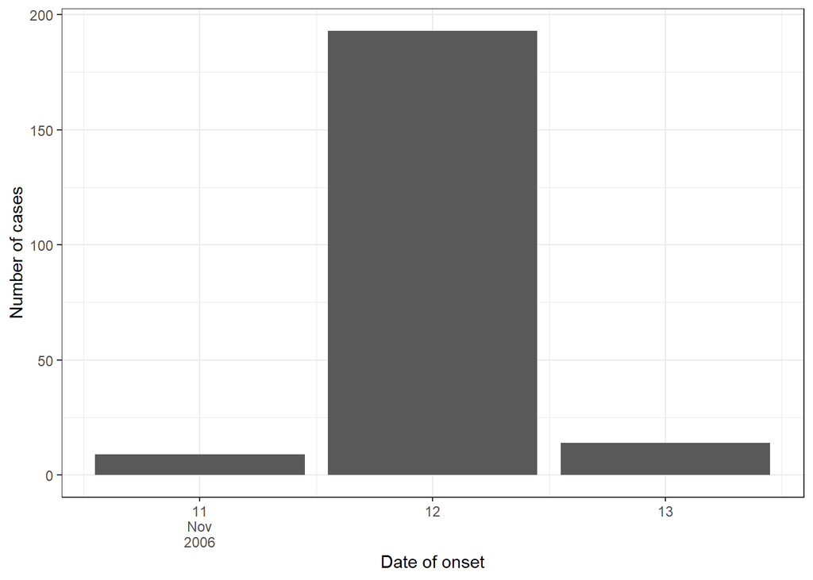

```r
# Fetch data:
epicurve_date <- linelist |>

  # Filter for cases where dayonset is not missing:
  filter(
    case == TRUE,
    !is.na(dayonset)
  ) |>

  # Add dayonset to ggplot aesthetic:
  ggplot(aes(x = dayonset)) +

  # Add the proper `geom_*` for a barplot:
  geom_bar() +

  # Adapt scale to data and adjust axis label angle:
  scale_x_datetime(
    date_breaks = "1 day",
    labels = scales::label_date_short()) +

  # Update x and y axis labels:
  labs(x = "Date of onset",
       y = "Number of cases") +

  # Remove unnecessary grid lines:
  theme_bw()

# Print epicurve:
epicurve_date
```

As you can see, the epicurve is quite crude, because most cases had their disease onset on 12 November. To increase resolution, we could enhance the time information to include both day and hour.

During the data preparation session, we already concatenated the variables `dayonset` and `starthour` together and formatted them with the `lubridate` package to create a new date-time variable called `onset_datetime`. We can now create the epicurve with this variable:

**Instructions**

Produce a 6-hours epicurve using a `barplot` of the `onset_datetime` variable (considering `case` only, and with missing values dropped out), using the `ggplot` function.

Set the following labels:

- x axis: “Date of onset”
- y axis: “Number of cases”

**Exercise**

```r
# Fetch data:
epicurve_hour <- linelist |>

  # Filter for cases where onset_datetime is not missing:
  filter(
    onset_datetime == TRUE,
    !___(onset_datetime)
  ) ___

  # Add onset_datetime to ggplot aesthetic:
  ggplot(aes(___ = onset_datetime)) ___

  # Add the proper `geom_*` for a barplot:
  ___() +

  # Adjust x axis scales to a suitable unit:
  scale_x_datetime(
    date_breaks = "6 hours",
    labels = scales::label_date_short()) +

  # Update x and y axis labels:
  ___(
    ___ = "Date and time of onset",
    ___ = "Number of cases"
  ) +


  # Remove unnecessary grid lines:
  theme_bw()

# Print epicurve:
epicurve_hour
```

**Solution**

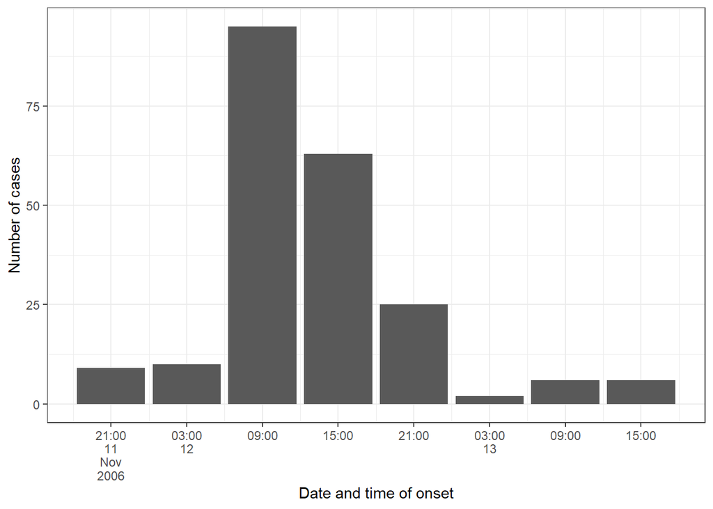

```r
# Fetch data:
epicurve_hour <- linelist |>

  # Filter for cases where dayonset is not missing:
  filter(
    case == TRUE,
    !is.na(onset_datetime)
  ) |>

  # Add onset_datetime to ggplot aesthetic:
  ggplot(aes(x = onset_datetime)) +

  # Add the proper `geom_*` for a barplot:
  geom_bar() +

  # Adjust x axis scales to a suitable unit:
  scale_x_datetime(
    date_breaks = "6 hours",
    labels = scales::label_date_short()) +

  # Update x and y axis labels:
  labs(
    x = "Date and time of onset",
    y = "Number of cases"
  ) +

  # Remove unnecessary grid lines:
  theme_bw()

# Print epicurve:
epicurve_hour
```

Finally, we could compare the epicurve between the sexes and additionally investigate how teachers versus students were distributed. Here, `fill` adds an additional variable to be displayed in the plot: `sex` is going to determine the fill-colour of our bars. `facet_wrap` splits the graph in two: one each for the two levels of `group`.

We will also use the function `str_glue()` to add the total number of cases to the sub-title of the plot. `str_glue()` is a very useful function that allows you to dynamically create a summary statistic from your data within some normal text.

**Instructions**

Produce a 6-hours epicurve using a `barplot` of the `onset_datetime` variable (considering `case` only, and with missing values dropped out), using the `ggplot` function. Superimpose the stratification by `sex`, and split the chart in two base on the `group` variable.

Set the following labels:

- x axis: “Date of onset”
- y axis: “Number of cases”
- fill legend title: “Sex”

**Exercise**

```r
# Fetch data:
epicurve_strata <- linelist |>

  # Filter for cases where onset_datetime is not missing:
  filter(
    ___ == TRUE,
    !___(___)
  ) |>

  # Add factor onset_day to ggplot aesthetic:
  ggplot(aes(___ = onset_datetime)) +

  # Add the proper `geom_*` for an "overall" barplot:
  ___() +

  # Superimpose the same `geom_*` for a barplot
  # stratified by sex:
  ___(___(fill = ___), position = "dodge") +

  # Adjust x axis scales to a suitable unit:
  scale_x_datetime(
    date_breaks = "6 hours",
    labels = scales::label_date_short()) +

  # Stratify by group:
  facet_wrap("group", nrow = 2) +

  # Update x and y axis labels:
  ___(
    ___ = "Date and time of onset",
    ___ = "Number of cases",
    ___ = "Sex",
    title = "Epicurve of the outbreak, overall (gray bars) and stratified by sex (coloured bars)",
    subtitle = str_glue(
      "Copenhagen, November 2006, N = {sum(linelist$case)}"
    )
  ) +

  # Add theme:
  theme_bw()

# Print epicurve:
epicurve_strata
```

**Solution**

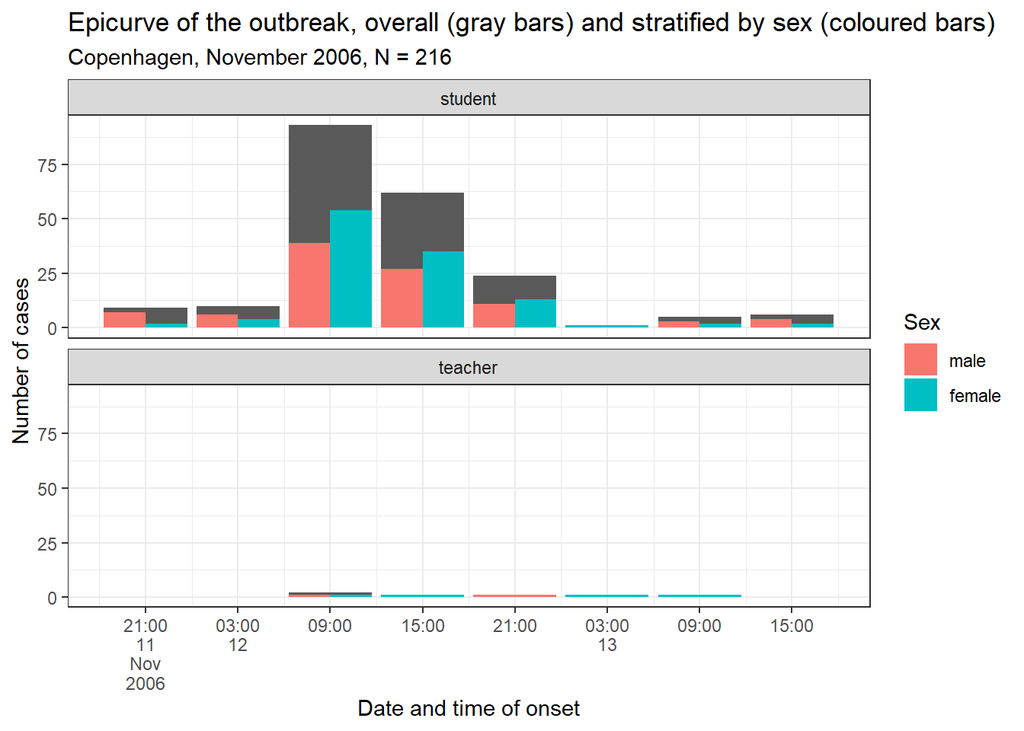

```r
# Fetch data:
epicurve_strata <- linelist |>

  # Filter for cases where onset_datetime is not missing:
  filter(
    case == TRUE,
    !is.na(onset_datetime)
  ) |>

  # Add factor onset_day to ggplot aesthetic:
  ggplot(aes(x = onset_datetime)) +

  # Add the proper `geom_*` for an "overall" barplot:
  geom_bar() +

  # Superimpose the same `geom_*` for a barplot
  # stratified by sex:
  geom_bar(aes(fill = sex), position = "dodge") +

  # Adjust x axis scales to a suitable unit:
  scale_x_datetime(
    date_breaks = "6 hours",
    labels = scales::label_date_short()) +

  # Stratify by group:
  facet_wrap("group", nrow = 2) +

  # Update x and y axis labels:
  labs(
    x = "Date and time of onset",
    y = "Number of cases",
    fill = "Sex",
    title = "Epicurve of the outbreak, overall (gray bars) and stratified by sex (coloured bars)",
    subtitle = str_glue(
      "Copenhagen, November 2006, N = {sum(linelist$case)}"
    )
  ) +

  # Add theme:
  theme_bw()

# Print epicurve:
epicurve_strata
```

## References

1.

Wickham H, Chang W, Henry L, Pedersen TL, Takahashi K, Wilke C, et al. ggplot2: Create elegant data visualisations using the grammar of graphics [Internet]. 2023. Available from: https://ggplot2.tidyverse.org

2.

Becker J, Chan C, Schoch D, Leeper TJ. Rio: A swiss-army knife for data i/o [Internet]. 2023. Available from: https://github.com/gesistsa/rio

3.

EPIET/OutbreakInvestigation [Internet]. Available from: https://github.com/EPIET/OutbreakInvestigation

4.

Wickham H. Tidyverse: Easily install and load the tidyverse [Internet]. 2023. Available from: https://tidyverse.tidyverse.org

5.

Müller K. Here: A simpler way to find your files [Internet]. 2020. Available from: https://here.r-lib.org/

6.

Rothman KJ, Greenland S, Lash TL. Modern epidemiology [Internet]. Third edition. Philadelphia: Wolters Kluwer Health/Lippincott Williams & Wilkins Philadelphia; 2008. Available from: http://www.r2library.com/public/ResourceDetail.aspx?authCheck=true&resid=2127